# 利用氣象資料以多組迴歸模型預測地下水位並相互比較

**謝芮云、白馨文、許天曜、蕭宇皓**

## 緒論

地下水在人類社會的用水結構中佔據著極為關鍵的比例，其重要性體現在農業灌溉、工業生產以及民生用水等多個領域。在臺灣，根據水利署全球資訊網的統計數據，如圖1所示，從民國103年至112年間，臺灣水資源利用的平均值中，地下水使用量佔比達到32.44%。這數據清晰地表明了地下水在臺灣整體用水體系中扮演的核心角色。從更宏觀的全球尺度來看，地下水的地位則更具主導性。在所有可利用的淡水資源中，排除難以直接取用的冰川儲量，地下水的佔比高達99%（Musie and Gonfa,2023）。如圖2所示，凸顯了地下水在全球淡水資源配置中的重要性。因此，如何維持地下水資源的穩定供應與實現永續利用，是當代水文與地球科學領域中極為重要的研究課題。

然而其水位波動機制複雜，不僅受氣溫、風速、降水等外部氣象因素驅動，更受到水文地質條件與水位本身的時間滯後效應影響。傳統的預測方法往往難以有效捕捉這種高度非線性的動態耦合關係。有鑑於此，本研究的動機是希望結合現代機器學習技術（如DNN、RNN及XGBoost），系統性地評估不同模型結構對時間序列特徵的敏感度。特別是，觀察水位本身前一小時值作為輸入參數時，對於模型預測精度的影響程度，藉此為水文預測選擇最優的建模策略。

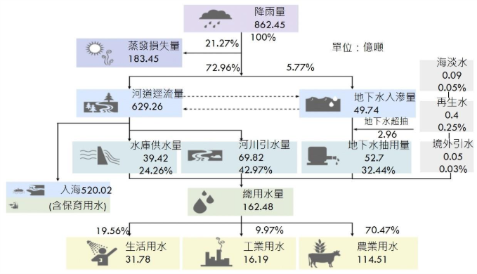

**圖 1： 民國103年至112年間，臺灣水資源來源與利用(水利署)。**

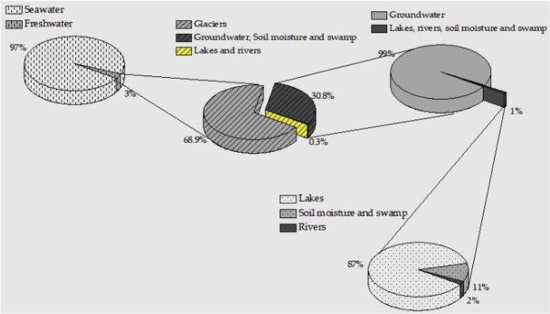

**圖 2： 全球水資源分布(Musie and Gonfa,2023)。**

本研究旨在達成以下三個主要目的 :

1.探討模型結構效能：在相同氣象和季節性特徵 (Case 1) 的輸入基礎下，對比 DNN、RNN 與 XGBoost 三種模型，評估其在預測非滯後水位時的相對優勢。

2.量化滯後參數價值：通過將前一小時地下水位納入輸入特徵 (Case 2)，量化此高度相關參數對三種模型預測誤差 (RMSE) 的改善幅度

3.識別最佳預測組合：綜合比較兩大情境的結果，識別出在有無滯後水位參數輸入時，表現最佳的模型，從而為實際應用提供最優的模型與特徵組合決策依據。

## 結果

對於輸入變數，我們分別建立「包含前一小時地下水位」與「不包含前一小時地下水位」兩種輸入變數組合，以下分別為三種模型架構的預測效能，包含深度神經網路 (Deep Neural Network, DNN)、循環神經網路 (Recurrent Neural Network, RNN) 與極限梯度提升 (eXtreme Gradient Boosting, XGBoost)。

### 深度學習網路（Deep Neural Network, DNN）

當前一小時地下水位未作為輸入變數，模型主要學到季節性特徵的變化(圖3)，觀察日變化可發現，模型預測效能非常有限。當加入前一小時作為輸入變數後(圖4)，模型預測效能極佳，說明地下水位的變化可能在一小時內並不大，模型只需直接參考前一小時地下水位，即可做出很好的預測。 模型最佳參數組合、誤差值與相關性如表1與表2，圖5表示模型誤差值與相關性。

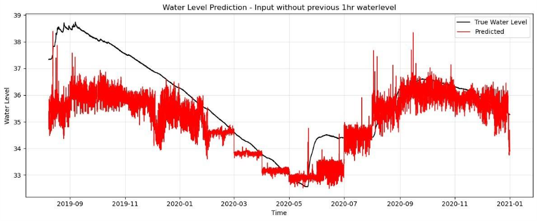

**圖 3： DNN模型預測結果時間序列(無地下水作為輸入參數)。**

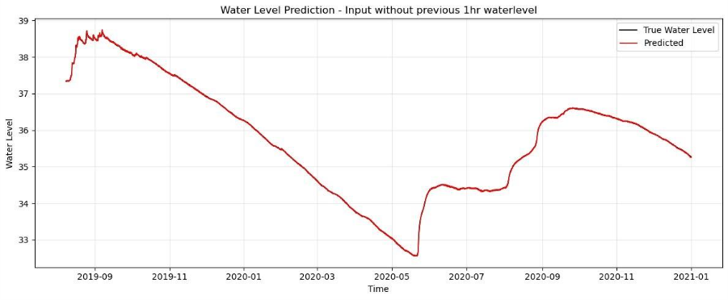

**圖 4： DNN模型預測結果時間序列(含地下水作為輸入參數)。**

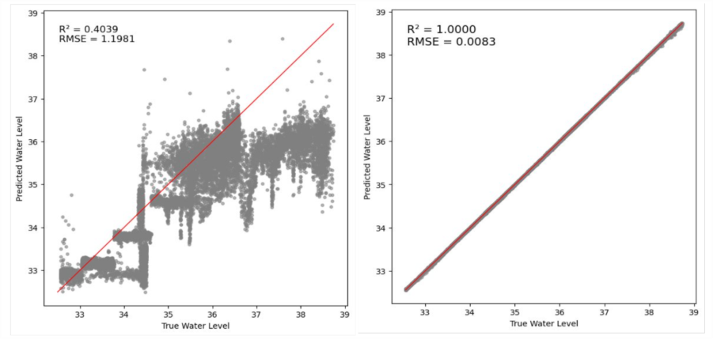

**圖 5： DNN模型誤差值與相關性。無地下水作為輸入參數(左)、有地下水作為輸入參數(右)。**

**表 1： DNN最佳參數組合、誤差值與相關性(無地下水作為輸入參數)。**

[output not shown]

**表 2： DNN最佳參數組合、誤差值與相關性（含地下水作為輸入參數）。**

| lr | batch_size | RMSE | R² |
| --- | --- | --- | --- |
| 0.0001 | 128 | 0.0083 | 1.0000 |

### 長短期記憶網路 (Long Short-Term Memory, LSTM)

[figure not shown]

**圖 6: LSTM模型預測結果時間序列 (無地下水作為輸入參數)。**

[figure not shown]

**圖 7: LSTM模型預測結果時間序列 (有地下水作為輸入參數)。**

[figure not shown]

**圖 8： LSTM模型誤差值與相關性。**

| Time_Steps_hr | LSTM_Units | LSTM_Layers | Epochs | RMSE | R² |
| --- | --- | --- | --- | --- | --- |
| 8 | 15 | 3 | 100 | 1.553 | 0.080 |

**表 4: LSTM最佳參數組合、誤值與相關性**

| Time_Steps_hr | LSTM_Units | LSTM_Layers | Epochs | RMSE | R² |
| --- | --- | --- | --- | --- | --- |
| 1 | 5 | 3 | 50 | 0.125 | 0.994 |

### 極限梯度提升（eXtreme Gradient Boosting, XGBoost）

[figure not shown]

**圖 9 : XGboost模型預測結果時間序列(無地下水作為輸入參數)。**

[figure not shown]

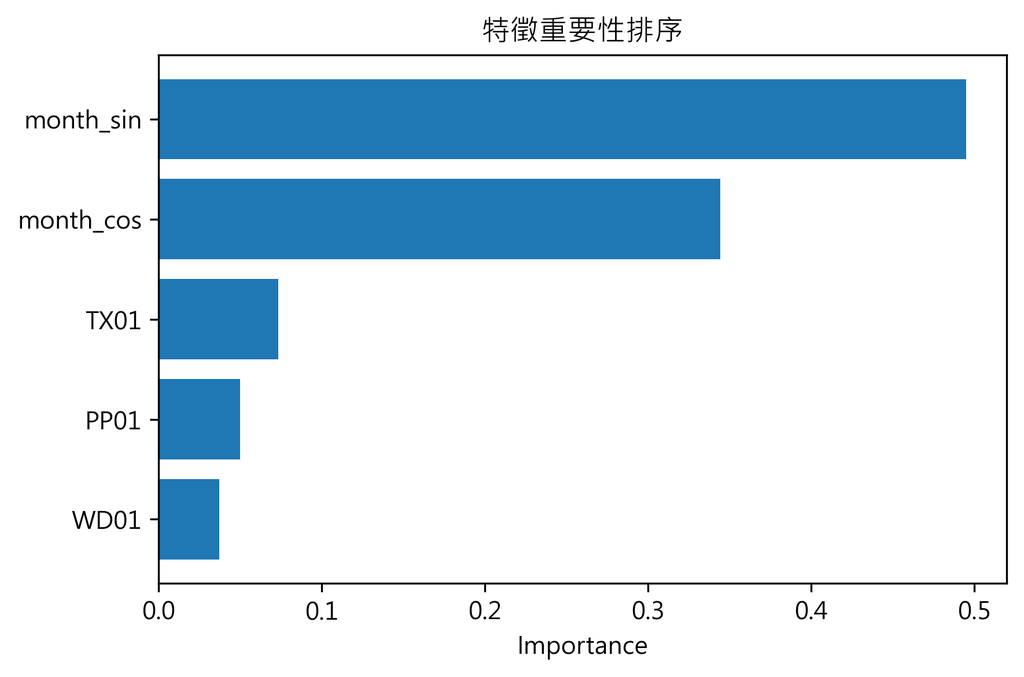

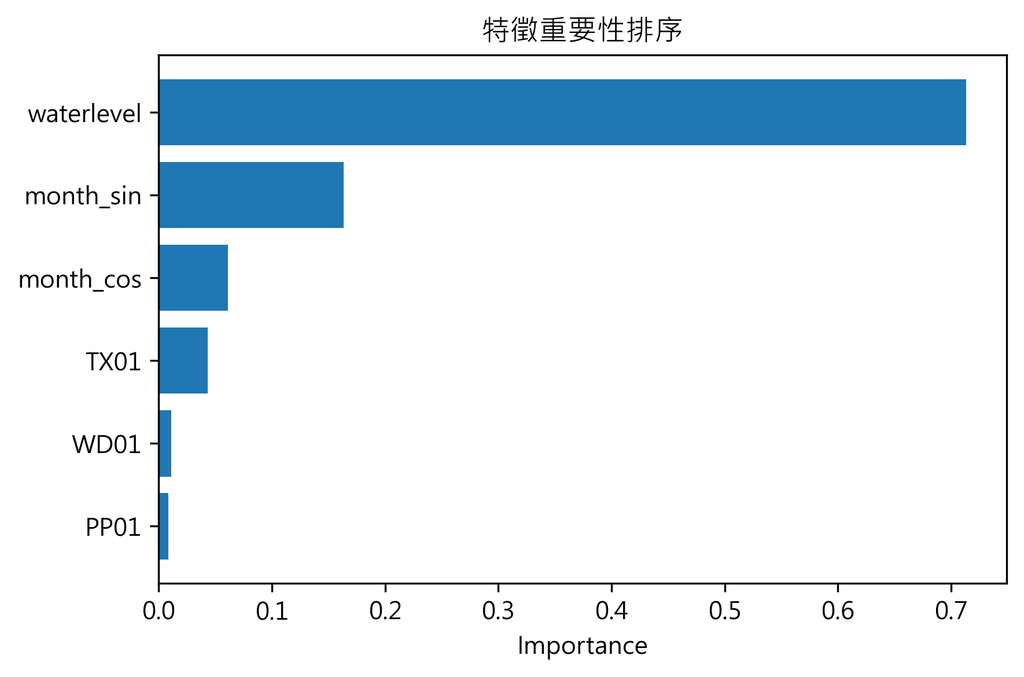

**圖 11 : XGboost上模型特徵重要性分析。無地下水作輸入參數(左)、含地下水作為輸入參數(右)。**

以XGBoost進行地下水位預測所得之最佳超參數組合及其誤差值與相關性如表5與表6，誤差值(RMSE)與相關性(R2)結果顯示，有輸入前一小時： 地下水作為預測參數之結果明顯優於無加入者。

**表 5 : XGboost最佳參數組合、誤差值與相關性 (無地下水做為輸入)**

| n_estimators | max_depth | learning_rate | subsample | RMSE | R² |
| --- | --- | --- | --- | --- | --- |
| 50 | 3 | 0.1 | 0.8 | 1.380 | 0.681 |

**表 6 : XGboost最佳參數組合、誤差值與相關性 (含地下水作為輸入)**

[output not shown]

## 討論

以下針對本研究結果進行以下幾點討論：

1. 在XGBoost中，本研究發現加入前一小時之地下水位進行預測，準確度皆較無加入者高，且前一小時地下水位在特徵重要性中居冠，可能原因為地下水在補注與抽取上，1小時內變化較小，因此建議將輸入資料時間延長，例如：前12小時。以上提供預測目的是高度準確的，若是要探討其餘因子對地下水位變化之影響，須從輸入參數中移除地下水位資料。若在無輸入地下水為作為輸入參數之情況下，特徵由時間週期性變化所主導，推測其原因可能為地下水位具時間週期性變化，如季節、抽水習慣等，由時間序列圖中可發現地下水位之預測值有週期性變化。
2. 在模型的初始嘗試中，我們將前一小時地下水位納入輸入特徵，結果顯示模型能取得相當小的預測誤差。然而，這樣的結果使我們思考模型建構的目的與其侷限性。因此，後續嘗試中我們將前一小時地下水位特徵移除，嘗試但純以降水量、風速、氣溫建構與地下水的關係，以測試在缺乏直接歷史水位資訊下的預測能力。其中問題在於過「哪些資料適合作為模型輸入變數，而哪些不適合」，也許是取決於研究的目標與模型欲回答的問題

## 結論

1.地下水位於1小時內變化較小，改為12小時以上較為適合。

2.撇除地下水位影響，地下水特徵由時間週期性變化所主導，其原因為地下水位具時間週期性變化，如季節、抽水習慣等

## 方法

我們分別使用 DNN、RNN、 XGBoost 三種回歸模型對地下水位進行預測，不同模型之原理將在本章節說明。

### 資料收集與前處理

1.資料蒐集

本研究針對欲分析之氣象與地下水變因進行資料蒐集，包含下列兩類資料來源 :

(1)氣象資料

取自交通部中央氣象署(Central Weather Administration, CWA)自動測站之每小時氣溫(TX01)(單位為攝氏溫度(℃))、風速(WD01)(單位為每小時公尺(m/s))與降雨量(PP01)(單位為毫米(mm))，以及測站地理資訊，於大氣水文資料庫取得。

(2)地下水資料

取自水利署水利規劃試驗所2021年「訊號分離技術應用於濁水溪沖積扇區域地下水文地質參數與抽補量推估」成果資料。該資料已完成異常值清理與缺值補遺，本研究直接採用期處理後之高品質每小時地下水位紀錄與地下水位站資訊(https://web.wra.gov.tw/wralib/WraLib/DocDownlervice?marc_id=92215)。 研究期間為2014年1月1日至2020年12月31日，共七年，為四項資料皆具有效紀錄且可比對的時間範圍。

2.研究區域與測站選取。

研究區域鎖定屏東平原，由於氣象自動測站與地下水觀測井位置不同，本研究採用空間距離最短的氣象與地下水配對組，以避免額外進行空間插值導致氣象資料失真，本研究選擇之配對為鹽埔氣象站(22.7396°N, 120.531°E)與彭厝(1)地下水站(22.7389°N, 120.532°E)，兩站僅相距約130公尺，可視為位於相同降雨場域，因此可直接以鹽埔站之降雨資料代表彭厝站的入滲條件。

[figure not shown]

**圖 12:研究站點位置(黃色標示為研究測站)。**

3.氣象資料前處理

為避免測站儀器誤差、校正不當或異常量測等因素造成不合理數據，本研究首先對氣象資料進行異常值檢查與移除。不同變數依其物理特性訂定合理範圍如下 :

(1) 降雨量

根據臺灣大學自動測站數據，於2021年6月4日下午1時至2時有紀錄降雨量高達209毫米，為目前最高時雨量，因此本研究將大於209毫米的降雨量數據視為極端值並予以移除。

(2) 氣溫

台灣平原區氣溫常見範圍約介於0至40度，根據高雄燈塔自動測站於2004年7月4日觀測之最高溫40.8度，本研究設定氣溫之合理範圍為-5度至41度，落於此範圍外之值皆視為極端值並移除。

(3) 風速

依照蒲福氏風級分類，每小時32.7公尺以上(約風力12級)，已屬陸上少見，且建築物普遍嚴重損毀之風速。因此本研究將風速大於每小時32.7公尺以上視為異常值於已剔除。 氣象資料之缺值比例分別為氣溫2.81%、風速2.81%、以及降雨2.55%，最大連續缺值筆數分別為25筆、25筆、24筆。缺值比例遠低於常見水文研究容許的 5至10% 門檻，且最大連續缺失時間僅為日尺度，因此造成的資料偏差極小。本研究採用線性插值法補遺，足以維持資料的時序連續性，不會影響後續趨勢判讀或模型結果。

(4) 地下水資料前處理

地下水水位資料的不確定性高，而進行模型訓練與預測時，高品質的水位資料是必須的。資料已由前期官方計畫完成異常值清理與補遺，因此有完整且連續的地下水水位紀錄，鑒於該流程已具備嚴格品質控管與驗證，本研究直接採用補遺後之水位資料作為模型輸入，但仍簡述其處理流程如下，以釐清資料來源品質：

i. 異常值偵測與資料清理

使用自動化異常值偵測流程，根據觀測井水位特性設定全域加乘係數、局部加乘係數、時間區間等參數，用以偵測異常水位跳動，系統偵測到異常後會予以移除，並以遞迴方式重複執行，直到資料序列中不再出現異常跳動，則完成清理流程。

ii. 趨勢及殘差項拆分與缺值補遺

將地下水位時間序列拆解為趨勢項與殘差項，補遺流程如下 :

A. 以局部加權迴歸（Locally Estimated Scatterplot Smoothing, LOESS）擬合水位趨勢。

B. 對趨勢使用線性插值法進行缺值補遺。

C. 對殘差項進行標準化。

D. 使用貝氏最大熵法（Bayesian Maximum Entropy, BME）推估殘差缺值。

E. 將補遺後殘差還原。

F. 趨勢項和殘差項重組，以得最終地下水位補遺值。

### 深度學習網路 (Deep Neural Network, DNN)

#### 模型解釋

深度神經網路（Deep Neural Network, DNN）透過輸入層與輸出層之間的多個隱藏層，將線性層與啟動函數（activation function）交替堆疊，使資料能逐層傳遞至下一層。其基本運算形式可表示為：

$$ y = \delta(w_1 x_1 + w_2 x_2 + w_3 x_3 + \cdots) + b $$

其中，$y$ 為輸出值，$x_i$ 為輸入特徵，$w_i$ 為對應之權重（weight）， $b$ 為偏差(bias)， $\delta$ 為激勵函數（此為ReLU function）。 此非線性轉換的目的，是讓模型能夠學習複雜且非線性的映射關係，透過多層傳遞建立輸入變數與目標變數之間的關係，並透過反向傳播（backpropagation）調整權重。

操作流程

#### 超參數設置

訓練過程中持續觀察訓練集與測試集的 RMSE 隨 epoch 的變化趨勢(圖14)，以確認模型未現過擬合情形。

[figure not shown]

圖13，超參數搜尋

[figure not shown]

圖14，訓練集與驗證集之損失曲線

#### DNN 模型程式碼如下 :

```
X_norm shape: (61366, 5)
y_norm shape: (61366, 1)
Train shape: (49092, 5)
Val shape: (12274, 5)
Using device: cuda

=== Try lr=0.0001, batch=128, hidden=128 ===
Early stopping at epoch 58
>>> Final Val Loss = 0.013055
       lr  batch  hidden  val_loss
0  0.0001    128     128  0.013055

==============================
Best Params: {'lr': 0.0001, 'batch_size': 128, 'hidden_dim': 128}
Best Val Loss: 0.013055145740509033
```

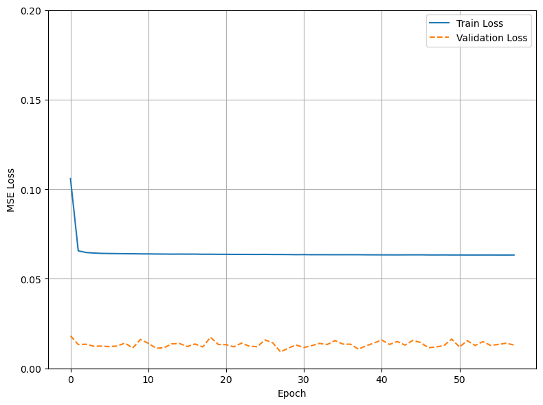

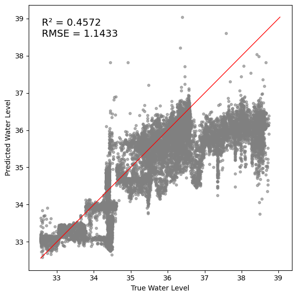

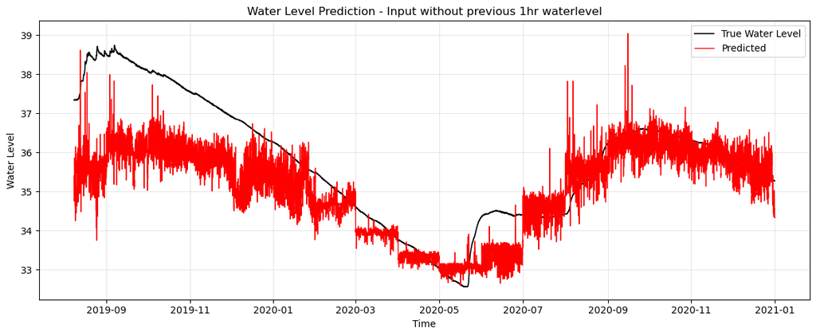

```python
### DNN Model

import numpy as np
import matplotlib.pyplot as plt
import pandas as pd
import copy

import torch
import torch.nn as nn
import torch.optim as optim
from torch.utils.data import TensorDataset, DataLoader


# =============== 1) Load data ===============
df = pd.read_csv("data_withmonth.csv")

# 確保有 Time 欄位且轉為 datetime
if "Time" in df.columns:
    df["Time"] = pd.to_datetime(df["Time"])
    time = df["Time"].values
else:
    raise ValueError("CSV 裡找不到 'Time' 欄位，請確認欄位名稱。")


# =============== 2) Make month_sin/cos if missing ===============
# 如果你的 CSV 已經有 month_sin/month_cos 就不動；沒有就用 Time 生成
if ("month_sin" not in df.columns) or ("month_cos" not in df.columns):
    month = pd.to_datetime(df["Time"]).dt.month
    df["month_sin"] = np.sin(2 * np.pi * month / 12)
    df["month_cos"] = np.cos(2 * np.pi * month / 12)


# =============== 3) Feature selection ===============
# without previous 1hr waterlevel
features = ["month_sin", "month_cos", "TX01", "WD01", "PP01"]

# with previous 1hr waterlevel
# features = ["month_sin", "month_cos", "TX01", "WD01", "PP01", "previous1hr_wl"]

target = "next1hr_wl"

# 檢查欄位是否存在
missing_feats = [c for c in features if c not in df.columns]
if missing_feats:
    raise ValueError(f"features 有欄位不存在：{missing_feats}")

if target not in df.columns:
    raise ValueError(f"target 欄位 '{target}' 不存在，請確認 CSV 欄位。")

X = df[features].values
y = df[target].values.reshape(-1, 1)


# =============== 4) Min-Max normalization ===============
eps = 1e-12

X_min = X.min(axis=0)
X_max = X.max(axis=0)
X_den = (X_max - X_min)
X_den = np.where(X_den == 0, eps, X_den)
X_norm = (X - X_min) / X_den

y_min = y.min()
y_max = y.max()
y_den = (y_max - y_min) if (y_max - y_min) != 0 else eps
y_norm = (y - y_min) / y_den

print("X_norm shape:", X_norm.shape)
print("y_norm shape:", y_norm.shape)


# =============== 5) Time-Series Split (80% Train / 20% Val) ===============
N = len(X_norm)
split_idx = int(N * 0.8)

X_train = X_norm[:split_idx]
y_train = y_norm[:split_idx]
time_train = time[:split_idx]

X_val = X_norm[split_idx:]
y_val = y_norm[split_idx:]
time_val = time[split_idx:]

print("Train shape:", X_train.shape)
print("Val shape:", X_val.shape)


# =============== 6) DNN model ===============
device = torch.device("cuda" if torch.cuda.is_available() else "cpu")
print("Using device:", device)


class DNN(nn.Module):
    def __init__(self, input_dim, hidden_dim=128):
        super().__init__()
        self.net = nn.Sequential(
            nn.Linear(input_dim, hidden_dim),
            nn.ReLU(),
            nn.Linear(hidden_dim, hidden_dim // 2),
            nn.ReLU(),
            nn.Linear(hidden_dim // 2, 1),
        )

    def forward(self, x):
        return self.net(x)


def train_model(
    model,
    X_train,
    y_train,
    X_val,
    y_val,
    epochs=300,
    lr=0.001,
    patience=30,
    batch_size=64,
):
    model = model.to(device)
    optimizer = optim.Adam(model.parameters(), lr=lr)
    loss_fn = nn.MSELoss()

    X_train_t = torch.tensor(X_train, dtype=torch.float32).to(device)
    y_train_t = torch.tensor(y_train, dtype=torch.float32).to(device)
    X_val_t = torch.tensor(X_val, dtype=torch.float32).to(device)
    y_val_t = torch.tensor(y_val, dtype=torch.float32).to(device)

    train_dataset = TensorDataset(X_train_t, y_train_t)
    train_loader = DataLoader(train_dataset, batch_size=batch_size, shuffle=True)

    train_losses = []
    val_losses = []

    best_val_loss = float("inf")
    wait = 0
    best_state = copy.deepcopy(model.state_dict())
    best_val_pred = None

    for ep in range(epochs):
        model.train()
        batch_losses = []

        for xb, yb in train_loader:
            optimizer.zero_grad()
            pred = model(xb)
            loss = loss_fn(pred, yb)
            loss.backward()
            optimizer.step()
            batch_losses.append(loss.item())

        train_loss = float(np.mean(batch_losses))

        model.eval()
        with torch.no_grad():
            val_pred = model(X_val_t)
            val_loss = loss_fn(val_pred, y_val_t).item()

        train_losses.append(train_loss)
        val_losses.append(val_loss)

        if val_loss < best_val_loss:
            best_val_loss = val_loss
            best_state = copy.deepcopy(model.state_dict())
            best_val_pred = val_pred.detach().cpu().numpy()
            wait = 0
        else:
            wait += 1

        if wait >= patience:
            print(f"Early stopping at epoch {ep + 1}")
            break

    model.load_state_dict(best_state)
    return model, train_losses, val_losses, best_val_pred


def r2_score_np(y_true, y_pred):
    y_true = np.asarray(y_true).reshape(-1)
    y_pred = np.asarray(y_pred).reshape(-1)
    ss_res = np.sum((y_true - y_pred) ** 2)
    ss_tot = np.sum((y_true - np.mean(y_true)) ** 2)
    return 1 - ss_res / ss_tot if ss_tot != 0 else np.nan


def rmse_np(y_true, y_pred):
    y_true = np.asarray(y_true).reshape(-1)
    y_pred = np.asarray(y_pred).reshape(-1)
    return np.sqrt(np.mean((y_true - y_pred) ** 2))


# =============== 7) Hyperparameter tuning ===============
lr_list = [1e-4]
batch_list = [128]
hidden_list = [128]

best_val_loss = float("inf")
best_params = None
best_model_state = None
best_val_pred_norm = None
best_train_losses = None
best_val_losses = None

results = []

for lr in lr_list:
    for batch in batch_list:
        for hidden in hidden_list:
            print(f"\n=== Try lr={lr}, batch={batch}, hidden={hidden} ===")

            model = DNN(input_dim=X_train.shape[1], hidden_dim=hidden)

            model, train_losses, val_losses, val_pred_norm = train_model(
                model,
                X_train,
                y_train,
                X_val,
                y_val,
                epochs=200,
                lr=lr,
                patience=30,
                batch_size=batch,
            )

            final_val = val_losses[-1]
            print(f">>> Final Val Loss = {final_val:.6f}")

            results.append({"lr": lr, "batch": batch, "hidden": hidden, "val_loss": final_val})

            if final_val < best_val_loss:
                best_val_loss = final_val
                best_params = {"lr": lr, "batch_size": batch, "hidden_dim": hidden}
                best_model_state = copy.deepcopy(model.state_dict())
                best_val_pred_norm = val_pred_norm
                best_train_losses = train_losses
                best_val_losses = val_losses

results_df = pd.DataFrame(results)
print(results_df)

print("\n==============================")
print("Best Params:", best_params)
print("Best Val Loss:", best_val_loss)


# =============== 8) Best model prediction ===============
best_model = DNN(input_dim=X_train.shape[1], hidden_dim=best_params["hidden_dim"])
best_model.load_state_dict(best_model_state)
best_model = best_model.to(device)

X_val_t = torch.tensor(X_val, dtype=torch.float32).to(device)

best_model.eval()
with torch.no_grad():
    pred_norm = best_model(X_val_t).cpu().numpy()

# 用 early-stopping 時記下的 best_val_pred（通常更一致）
if best_val_pred_norm is not None:
    pred_norm = best_val_pred_norm

pred_real = pred_norm * (y_max - y_min) + y_min
y_val_real = y_val * (y_max - y_min) + y_min

time_real = time_val


# =============== 9) Loss curve ===============
plt.figure(figsize=(8, 6))
plt.plot(best_train_losses, label="Train Loss")
plt.plot(best_val_losses, label="Validation Loss", linestyle="--")
plt.xlabel("Epoch")
plt.ylabel("MSE Loss")
plt.ylim(0, 0.2)
plt.yticks([0.00, 0.05, 0.10, 0.15, 0.20])
plt.legend()
plt.grid(True)
plt.tight_layout()
plt.show()


# =============== 10) True vs Pred scatter ===============
plt.figure(figsize=(6, 6))
plt.scatter(y_val_real, pred_real, s=12, color="gray", alpha=0.6)

min_v = min(y_val_real.min(), pred_real.min())
max_v = max(y_val_real.max(), pred_real.max())
plt.plot([min_v, max_v], [min_v, max_v], color="red", linewidth=1)

plt.xlabel("True Water Level")
plt.ylabel("Predicted Water Level")

plt.text(
    0.05, 0.95,
    f"R² = {r2_score_np(y_val_real, pred_real):.4f}\nRMSE = {rmse_np(y_val_real, pred_real):.4f}",
    transform=plt.gca().transAxes,
    fontsize=14,
    verticalalignment="top"
)

plt.tight_layout()
plt.show()


# =============== 11) Time series plot ===============
sort_idx = np.argsort(time_real)

plt.figure(figsize=(12, 5))
plt.plot(
    time_real[sort_idx],
    y_val_real.reshape(-1)[sort_idx],
    label="True Water Level",
    color="black",
    linewidth=1.2,
)

plt.plot(
    time_real[sort_idx],
    pred_real.reshape(-1)[sort_idx],
    label="Predicted",
    color="red",
    linewidth=1,
)

plt.xlabel("Time")
plt.ylabel("Water Level")
plt.title("Water Level Prediction - Input without previous 1hr waterlevel")
plt.legend()
plt.grid(True, alpha=0.3)
plt.tight_layout()
plt.show()
```

### 長短期記憶網路（Long Short-Term Memory, LSTM）

標準 RNN 在序列很長時會遇到 梯度消失 問題，使其無法學習數天前的遠距離依賴關係。LSTM 透過引入門控機制（遺忘門、輸入門、輸出門）和一個獨立的細胞狀態 (Cell State)。這個機制使其能夠選擇性地控制資訊流，有效保存或忽略數小時前的數據，從而穩定地捕捉水文數據中降水影響的延遲效應，遺忘門、輸入門、輸出門由python 中的tensorflow套件自動控制。

1.遺忘門 (Forget Gate): 決定哪些資訊應該被丟棄，以騰出空間給新資訊。

2.輸入門 (Input Gate): 決定當前時間步的哪些新資訊應該被加入到細胞狀態中。

3.輸出門 (Output Gate): 決定基於更新後的細胞狀態，應該把哪些資訊輸出作為當前的預測結果。

#### 操作流程

超參數設置

Time_steps_options = [1, 3, 8] --> [1, 8]

Train_ratio_options = [0.7, 0.8, 0.9] --> [0.8]

Lstm_units_options = [3, 5, 10] --> [5, 10, 15]

Lstm_layers_options = [3, 5, 10] --> [3, 5]

Epochs_options = [5, 10, 50] --> [50, 100]

為達到同時節省訓練時間以及精進模型的目的調整超參數網格。

#### RNN 模型程式碼如下 :

```python
### RNN Model


import pandas as pd
import numpy as np
import matplotlib.pyplot as plt
import seaborn as sns
import os

from sklearn.preprocessing import MinMaxScaler
from sklearn.metrics import mean_squared_error

from tensorflow.keras.models import Sequential
from tensorflow.keras.layers import LSTM, Dense
from tensorflow.keras import mixed_precision

import warnings
warnings.filterwarnings('ignore')  # 抑制特定警告


# --- 1. Set Hyperparameter Options ---
TIME_STEPS_OPTIONS = [1]
TRAIN_RATIO_OPTIONS = [0.8]
LSTM_UNITS_OPTIONS = [10]
LSTM_LAYERS_OPTIONS = [5]
EPOCHS_OPTIONS = [50]

results = []
test_count = 0


# --- 2. Data Loading and Preprocessing (新增季節性特徵計算) ---
file_path = 'data1.xlsx'
df = None
data_len = 500
np.random.seed(42)  # 設置種子確保模擬數據可重現
date_range = None


# --- A. 嘗試加載真實數據 ---
try:
    df = pd.read_excel(file_path, sheet_name='Sheet1')
    print(f"✅ Successfully loaded data from '{file_path}'. Data shape: {df.shape}")

    # 假設 Excel 數據有一個 'Date' 或類似的日期時間欄位
    if 'Date' in df.columns:
        df = df.set_index('Date').sort_index()
    elif df.index.dtype != 'datetime64[ns]':
        # 如果沒有日期索引，且不是日期類型，則創建模擬日期索引
        data_len = len(df)
        end_date = pd.to_datetime('2025-12-05')
        date_range = pd.date_range(end=end_date, periods=data_len, freq='D')
        df.index = date_range
        print(
            f"❗ No explicit date column found. "
            f"Assigned a simulated daily date index of length {data_len}."
        )

except Exception as e:
    print(f"❌ Error: Failed to read file '{file_path}'. Using simulated data.")
    print(f"Detailed Error: {e}")

    # --- B. 使用模擬數據 ---
    data_len = 500
    end_date = pd.to_datetime('2025-12-05')
    date_range = pd.date_range(end=end_date, periods=data_len, freq='D')

    df = pd.DataFrame(
        {
            'TX01': 20 + 5 * np.random.rand(data_len),
            'WD01': 5 + 2 * np.random.rand(data_len),
            'PP01': np.cumsum(0.1 * np.random.rand(data_len) - 0.05),
            'waterlevel': (
                10
                + 2 * np.sin(np.linspace(0, 10, data_len))
                + 0.5 * np.random.rand(data_len)
            ),
        },
        index=date_range,
    )
    print("✅ Using simulated data for demonstration with a date index.")


# --- C. 計算月份的循環特徵 (新增) ---
# 確保索引是日期時間類型
if not isinstance(df.index, pd.DatetimeIndex):
    print("Error: DataFrame index is not DatetimeIndex. Cannot calculate month features.")
    # 退出或使用一個默認值 (此處為簡單退出)
    # exit()

df['month'] = df.index.month
month_period = 12
df['month_sin'] = np.sin(2 * np.pi * df['month'] / month_period)
df['month_cos'] = np.cos(2 * np.pi * df['month'] / month_period)
df = df.drop(columns=['month'])  # 移除輔助欄位


# --- D. 定義更新後的情境特徵集 ---
TARGET = ['waterlevel']
NEW_FEATURES = ['month_cos', 'month_sin']

# Case 1: 氣象特徵 + 季節性特徵
FEATURES_CASE_1 = ['TX01', 'WD01', 'PP01'] + NEW_FEATURES

# Case 2: 氣象特徵 + 季節性特徵 + 滯後目標
FEATURES_CASE_2 = ['TX01', 'WD01', 'PP01', 'waterlevel'] + NEW_FEATURES

print(f"\n--- Feature Sets Updated ---")
print(f"Case 1 Features: {FEATURES_CASE_1}")
print(f"Case 2 Features: {FEATURES_CASE_2}")
print("--------------------------")


# 初始化 Scalers
scaler_y = MinMaxScaler(feature_range=(0, 1))
scaled_y = scaler_y.fit_transform(df[TARGET].values)


# Function to create time series sequences
def create_sequences(X, y, time_steps):
    """Converts features and target data into sequences for LSTM training."""
    Xs, ys = [], []

    if len(X) <= time_steps:
        return np.array([]), np.array([])

    for i in range(len(X) - time_steps):
        # 輸入 X 是 t-T 到 t-1 的數據 (共 T 個時間步)
        Xs.append(X[i:(i + time_steps)])
        # 輸出 y 是 t 的數據 (即 t-1 + 1)
        ys.append(y[i + time_steps])

    return np.array(Xs), np.array(ys)


# --- 3. Main Grid Search Loop ---
SCENARIOS = {
    'Case 1: Features Only (incl. seasonality)': FEATURES_CASE_1,
    'Case 2: Features + Lagged Target (incl. seasonality)': FEATURES_CASE_2,
}


# 計算總測試次數
total_tests = (
    len(TIME_STEPS_OPTIONS)
    * len(TRAIN_RATIO_OPTIONS)
    * len(LSTM_UNITS_OPTIONS)
    * len(LSTM_LAYERS_OPTIONS)
    * len(EPOCHS_OPTIONS)
    * len(SCENARIOS)
)
print(
    f"\n--- Starting Automated Grid Search Tuning "
    f"(Total {total_tests} tests over {len(SCENARIOS)} scenarios) ---"
)

test_count = 0
results = []


for scenario_name, features in SCENARIOS.items():
    print(f"\n################ SCENARIO: {scenario_name} ################")

    # 針對當前情境重新縮放輸入數據
    data_X_current = df[features].values
    scaler_X_current = MinMaxScaler(feature_range=(0, 1))
    scaled_X_current = scaler_X_current.fit_transform(data_X_current)

    for time_steps in TIME_STEPS_OPTIONS:

        # 創建序列
        X_seq, y_seq = create_sequences(scaled_X_current, scaled_y, time_steps)

        if len(X_seq) < 50:
            print(
                f"Skipping scenario {scenario_name} with T={time_steps}: "
                f"Not enough sequential data ({len(X_seq)} samples)."
            )
            continue

        for train_ratio in TRAIN_RATIO_OPTIONS:
            train_size = int(len(X_seq) * train_ratio)

            X_train, X_test = X_seq[:train_size], X_seq[train_size:]
            y_train, y_test = y_seq[:train_size], y_seq[train_size:]

            # 用於 RMSE 計算的原始尺度目標值
            y_test_original_for_rmse = scaler_y.inverse_transform(y_test)
            y_train_original_for_rmse = scaler_y.inverse_transform(y_train)

            for lstm_units in LSTM_UNITS_OPTIONS:
                for lstm_layers in LSTM_LAYERS_OPTIONS:
                    for epochs in EPOCHS_OPTIONS:

                        test_count += 1

                        # --- 進度列印 ---
                        print(
                            f"\n--- Test {test_count}/{total_tests} [{scenario_name}]: "
                            f"T={time_steps}, R={train_ratio*100}%, "
                            f"U={lstm_units}, L={lstm_layers}, E={epochs} ---"
                        )

                        # --- Model Construction ---
                        model = Sequential()
```

```python
                        try:
                            # 構建多層 LSTM
                            for i in range(lstm_layers):
                                is_last_layer = (i == lstm_layers - 1)
                                input_shape = (
                                    (time_steps, X_train.shape[2]) if i == 0 else None
                                )

                                model.add(
                                    LSTM(
                                        units=lstm_units,
                                        activation='tanh',
                                        return_sequences=not is_last_layer,
                                        input_shape=input_shape,
                                    )
                                )

                            # 輸出層
                            model.add(Dense(units=1, activation='linear'))
                            model.compile(optimizer='adam', loss='mse')

                        except Exception as e:
                            print(f"  Error building model: {e}")
                            results.append(
                                {
                                    'Scenario': scenario_name,
                                    'Time_Steps_hr': time_steps,
                                    'Train_Ratio': train_ratio,
                                    'LSTM_Units': lstm_units,
                                    'LSTM_Layers': lstm_layers,
                                    'Epochs': epochs,
                                    'RMSE': np.nan,
                                    'Training_RMSE': np.nan,
                                    'Features': ', '.join(features),
                                }
                            )
                            continue

                        # --- Training and Evaluation ---
                        try:
                            # 訓練模型 (verbose=0，保持簡潔)
                            model.fit(
                                X_train,
                                y_train,
                                epochs=epochs,
                                batch_size=32,
                                verbose=0,
                                shuffle=False,
                            )

                            # Test RMSE Calculation
                            y_pred_scaled = model.predict(X_test, verbose=0)
                            y_pred_original = scaler_y.inverse_transform(y_pred_scaled)
                            test_rmse = np.sqrt(
                                mean_squared_error(
                                    y_test_original_for_rmse,
                                    y_pred_original,
                                )
                            )

                            # Training RMSE Calculation
                            y_train_pred_scaled = model.predict(X_train, verbose=0)
                            y_train_pred_original = scaler_y.inverse_transform(
                                y_train_pred_scaled
                            )
                            train_rmse = np.sqrt(
                                mean_squared_error(
                                    y_train_original_for_rmse,
                                    y_train_pred_original,
                                )
                            )

                            print(
                                f"  --> Test RMSE: {test_rmse:.4f}, "
                                f"Train RMSE: {train_rmse:.4f}"
                            )

                            results.append(
                                {
                                    'Scenario': scenario_name,
                                    'Features': ', '.join(features),
                                    'Time_Steps_hr': time_steps,
                                    'Train_Ratio': train_ratio,
                                    'LSTM_Units': lstm_units,
                                    'LSTM_Layers': lstm_layers,
                                    'Epochs': epochs,
                                    'RMSE': test_rmse,
                                    'Training_RMSE': train_rmse,
                                }
                            )

                        except Exception as e:
                            print(f"  Error during training or evaluation: {e}")
                            results.append(
                                {
                                    'Scenario': scenario_name,
                                    'Time_Steps_hr': time_steps,
                                    'Train_Ratio': train_ratio,
                                    'LSTM_Units': lstm_units,
                                    'LSTM_Layers': lstm_layers,
                                    'Epochs': epochs,
                                    'RMSE': np.nan,
                                    'Training_RMSE': np.nan,
                                    'Features': ', '.join(features),
                                }
                            )


# --- 4. Result Compilation and Output ---
print("\n--- Grid Search Tuning Complete ---")
results_df = pd.DataFrame(results)

# 按照情境和 Test RMSE 排序
results_df_sorted = (
    results_df.sort_values(by=['Scenario', 'RMSE'])
    .dropna()
    .reset_index(drop=True)
)

# Output CSV file
output_file = 'lstm_single_step_tuning_results_with_seasonality.csv'
results_df_sorted.to_csv(output_file, index=False)
print(f"\nAll test results saved and sorted to file: {output_file}")


# --- 5. Tabular Output (Display best models for each scenario) ---
print("\n--- Best Model Combinations per Scenario (Sorted by Test RMSE) ---")

best_case1 = results_df_sorted[
    results_df_sorted['Scenario'].str.contains('Case 1')
].head(1)

best_case2 = results_df_sorted[
    results_df_sorted['Scenario'].str.contains('Case 2')
].head(1)

print("\n### Case 1: TX01, WD01, PP01, Month_Features -> Waterlevel (Best) ###")
print(
    best_case1[
        ['Time_Steps_hr', 'LSTM_Units', 'LSTM_Layers', 'Epochs', 'RMSE', 'Training_RMSE']
    ].to_string(index=False)
)
```

```python
print("\n### Case 2: TX01, WD01, PP01, Waterlevel(t-1), Month_Features -> Waterlevel(t) (Best) ###")
print(
    best_case2[
        ['Time_Steps_hr', 'LSTM_Units', 'LSTM_Layers', 'Epochs', 'RMSE', 'Training_RMSE']
    ].to_string(index=False)
)


# --- 6. Visualization Output (情境比較 Bar Chart) ---
print("\n--- Generating Scenario Comparison Chart (Bar Chart) ---")


def plot_scenario_comparison(df, filename):
    """Compares the average RMSE and best RMSE between the two scenarios."""
    successful_scenarios = df['Scenario'].unique()

    if len(successful_scenarios) < 2:
        print("Warning: Only one scenario ran successfully. Skipping comparison plot.")
        return

    # 計算平均和最佳 RMSE
    avg_rmse = df.groupby('Scenario')['RMSE'].mean().reset_index()
    avg_rmse.rename(columns={'RMSE': 'Average RMSE'}, inplace=True)

    best_rmse = df.groupby('Scenario')['RMSE'].min().reset_index()
    best_rmse.rename(columns={'RMSE': 'Best RMSE'}, inplace=True)

    plot_data = pd.merge(avg_rmse, best_rmse, on='Scenario')
    plot_data = plot_data.set_index('Scenario').T  # 轉置以便繪圖

    plt.figure(figsize=(10, 6))
    plot_data.plot(kind='bar', ax=plt.gca(), cmap='viridis', rot=0)

    plt.title(
        'Comparison of Prediction Errors (RMSE) Across Scenarios (With Seasonality)',
        fontsize=14,
    )
    plt.ylabel('RMSE (Original Scale)', fontsize=12)
    plt.xlabel('Metric', fontsize=12)
    plt.legend(title='Scenario', fontsize=10)
    plt.grid(axis='y', linestyle='--', alpha=0.7)
    plt.tight_layout()
    plt.savefig(filename)
    plt.close()


plot_scenario_comparison(
    results_df_sorted,
    'scenario_comparison_rmse_with_seasonality.png',
)

print(
    "Comparison chart for Case 1 vs Case 2 has been generated: "
    "scenario_comparison_rmse_with_seasonality.png"
)


# --- 7. Best Model Prediction Plots (個別輸出 Case 1 和 Case 2 最佳圖) ---
print("\n--- 7. Generating Time Series Comparison Plots for BEST Case 1 and BEST Case 2 ---")


def generate_best_plot(best_params_df, scenario_name, features_list, df, scaler_y, plot_suffix):
    """Rebuilds, trains, predicts, and plots the results for a single best model."""
    if best_params_df.empty:
        print(f"  -> Skipping plot for {scenario_name}: No successful best model found.")
        return

    best_params = best_params_df.iloc[0]  # 確保只取一行數據
    best_time_steps = int(best_params['Time_Steps_hr'])

    # 重新處理該情境的數據
    data_X_current = df[features_list].values
    scaler_X_current = MinMaxScaler(feature_range=(0, 1))
    scaled_X_current = scaler_X_current.fit_transform(data_X_current)

    X_seq_best, y_seq_best = create_sequences(
        scaled_X_current,
        scaled_y,
        best_time_steps,
    )

    best_train_ratio = best_params['Train_Ratio']
    train_size_best = int(len(X_seq_best) * best_train_ratio)

    X_train_best = X_seq_best[:train_size_best]
    y_train_best = y_seq_best[:train_size_best]
    X_test_best = X_seq_best[train_size_best:]
    y_test_original_best = scaler_y.inverse_transform(
        y_seq_best[train_size_best:]
    )

    # 重新構建和訓練模型
    best_model = Sequential()

    try:
        for i in range(int(best_params['LSTM_Layers'])):
            is_last_layer = (i == int(best_params['LSTM_Layers']) - 1)
            input_shape = (
                (best_time_steps, X_train_best.shape[2]) if i == 0 else None
            )

            best_model.add(
                LSTM(
                    units=int(best_params['LSTM_Units']),
                    activation='relu',
                    return_sequences=not is_last_layer,
                    input_shape=input_shape,
                )
            )

        best_model.add(Dense(units=1, activation='linear'))
        best_model.compile(optimizer='adam', loss='mse')

    except Exception as e:
        print(f"  -> Error rebuilding model for plotting: {e}")
        return

    best_model.fit(
        X_train_best,
        y_train_best,
        epochs=int(best_params['Epochs']),
        batch_size=32,
        verbose=0,
        shuffle=False,
    )

    # 進行預測
    y_pred_scaled_best = best_model.predict(X_test_best, verbose=0)
    y_pred_original_best = scaler_y.inverse_transform(y_pred_scaled_best)

    # 繪製時間序列圖
    plt.figure(figsize=(15, 7))
    plt.plot(
        y_test_original_best.flatten(),
        label='Actual Water Level',
        color='blue',
        linewidth=2,
    )
    plt.plot(
        y_pred_original_best.flatten(),
        label='Predicted Water Level',
        color='red',
        linestyle='--',
        linewidth=1.5,
    )

    title = (
        f'Water Level Prediction vs. Actual ({scenario_name}) - Test Set\n'
        f'RMSE: {best_params["RMSE"]:.4f}, '
        f'T={best_time_steps}h, '
        f'U={int(best_params["LSTM_Units"])}, '
        f'L={int(best_params["LSTM_Layers"])}, '
        f'E={int(best_params["Epochs"])}'
    )
    plt.title(title, fontsize=16)

    plt.xlabel(
        f'Time Step ({best_train_ratio*100:.0f}% Training / '
        f'{100-best_train_ratio*100:.0f}% Test)',
        fontsize=12,
    )
    plt.ylabel('Water Level (Original Scale)', fontsize=12)
    plt.legend(fontsize=12)
    plt.grid(True, linestyle=':', alpha=0.7)

    plot_filename = f'best_model_{plot_suffix}_with_seasonality.png'
    plt.tight_layout()
    plt.savefig(plot_filename)
    plt.close()

    print(
        f"  -> Prediction comparison plot for {scenario_name} "
        f"saved to: {plot_filename}"
    )


# 執行 Case 1 最佳模型的繪圖
generate_best_plot(
    best_case1,
    'Case 1: Features Only (incl. seasonality)',
    FEATURES_CASE_1,
    df,
    scaler_y,
    'case1',
)

# 執行 Case 2 最佳模型的繪圖
generate_best_plot(
    best_case2,
    'Case 2: Features + Lagged Target (incl. seasonality)',
    FEATURES_CASE_2,
    df,
    scaler_y,
    'case2',
)


# --- 8. Hyperparameter Importance Analysis (藉由 RMSE 分佈比較) ---
print("\n--- 8. Analyzing Hyperparameter Influence on Test RMSE (Feature Importance Proxy) ---")


def plot_hyperparameter_influence(df, hyperparameter, title, filename):
    """
    Plots the distribution of Test RMSE for different settings of a hyperparameter.
    Uses Box Plot for distribution visualization.
    """
    if df.empty or df['RMSE'].isnull().all():
        print(
            f"Warning: No successful test results available to analyze {hyperparameter}."
        )
        return
```

```python
    # 準備繪圖數據
    plot_df = df.copy()

    if hyperparameter not in ['Scenario', 'Features']:
        plot_df[hyperparameter] = plot_df[hyperparameter].astype(str)
        order = sorted(
            plot_df[hyperparameter].unique(),
            key=lambda x: (int(x) if x.isdigit() else x),
        )
    else:
        order = None

    successful_df = plot_df.dropna(subset=['RMSE'])

    plt.figure(figsize=(10, 6))

    # 繪製箱形圖
    sns.boxplot(
        x=hyperparameter,
        y='RMSE',
        data=successful_df,
        order=order,
        palette='Set2',
    )

    # 標記平均 RMSE
    if successful_df[hyperparameter].nunique() > 1:
        x_labels = plt.gca().get_xticklabels()
        label_to_index = {
            label.get_text(): i for i, label in enumerate(x_labels)
        }

        mean_rmses = (
            successful_df.groupby(hyperparameter)['RMSE']
            .mean()
            .reset_index()
        )

        for _, row in mean_rmses.iterrows():
            param_value = str(row[hyperparameter])
            if param_value in label_to_index:
                x_pos = label_to_index[param_value]
                plt.scatter(
                    x_pos,
                    row['RMSE'],
                    color='red',
                    marker='o',
                    s=100,
                    zorder=5,
                )
                if len(x_labels) <= 5:
                    plt.text(
                        x_pos,
                        row['RMSE'],
                        f'{row["RMSE"]:.3f}',
                        ha='center',
                        va='bottom',
                        fontsize=10,
                        color='red',
                    )

    plt.title(title, fontsize=14)
    plt.ylabel('Test RMSE (Original Scale)', fontsize=12)
    plt.xlabel(f'{hyperparameter} Setting', fontsize=12)
    plt.grid(axis='y', linestyle='--', alpha=0.7)
    plt.tight_layout()

    filename = filename.replace('.png', '_with_seasonality.png')
    plt.savefig(filename)
    plt.close()

    print(f"  -> Influence plot for '{hyperparameter}' saved to: {filename}")


print("\n分析完成。所有結果已輸出到 CSV 文件和 PNG 圖像。")
```

```
❌ Error: Failed to read file 'data1.xlsx'. Using simulated data.
Detailed Error: [Errno 2] No such file or directory: 'data1.xlsx'
✅ Using simulated data for demonstration with a date index.

--- Feature Sets Updated ---
Case 1 Features: ['TX01', 'WD01', 'PP01', 'month_cos', 'month_sin']
Case 2 Features: ['TX01', 'WD01', 'PP01', 'waterlevel', 'month_cos', 'month_sin']
--------------------------

--- Starting Automated Grid Search Tuning (Total 2 tests over 2 scenarios) ---

################ SCENARIO: Case 1: Features Only (incl. seasonality) ################

--- Test 1/2 [Case 1: Features Only (incl. seasonality)]: T=1, R=80.0%, U=10, L=5, E=50 ---
  --> Test RMSE: 1.4145, Train RMSE: 0.5767

################ SCENARIO: Case 2: Features + Lagged Target (incl. seasonality) ################

--- Test 2/2 [Case 2: Features + Lagged Target (incl. seasonality)]: T=1, R=80.0%, U=10, L=5, E=50 ---
  --> Test RMSE: 0.3472, Train RMSE: 0.3035

--- Grid Search Tuning Complete ---

All test results saved and sorted to file: lstm_single_step_tuning_results_with_seasonality.csv

--- Best Model Combinations per Scenario (Sorted by Test RMSE) ---

### Case 1: TX01, WD01, PP01, Month_Features -> Waterlevel (Best) ###
 Time_Steps_hr  LSTM_Units  LSTM_Layers  Epochs    RMSE  Training_RMSE
             1          10            5      50 1.41451       0.576685

### Case 2: TX01, WD01, PP01, Waterlevel(t-1), Month_Features -> Waterlevel(t) (Best) ###
 Time_Steps_hr  LSTM_Units  LSTM_Layers  Epochs    RMSE  Training_RMSE
             1          10            5      50 0.34724       0.303537

--- Generating Scenario Comparison Chart (Bar Chart) ---
Comparison chart for Case 1 vs Case 2 has been generated: scenario_comparison_rmse_with_seasonality.png

--- 7. Generating Time Series Comparison Plots for BEST Case 1 and BEST Case 2 ---
  -> Prediction comparison plot for Case 1: Features Only (incl. seasonality) saved to: best_model_case1_with_seasonality.png
WARNING:tensorflow:5 out of the last 22 calls to <function TensorFlowTrainer.make_predict_function.<locals>.one_step_on_data_distributed at 0x000001B4343FAFC0> triggered tf.function retracing. Tracing is expensive and the excessive number of tracings could be due to (1) creating @tf.function repeate…
  -> Prediction comparison plot for Case 2: Features + Lagged Target (incl. seasonality) saved to: best_model_case2_with_seasonality.png

--- 8. Analyzing Hyperparameter Influence on Test RMSE (Feature Importance Proxy) ---

分析完成。所有結果已輸出到 CSV 文件和 PNG 圖像。
```

### XGBoost

#### 模型解釋

Ayus, I. et al. (2023)利用機器學習與深度學習技術預測水位，比較 Random Forest 、XGBoost、bidirectional LSTM、convolutional 1D-BiLSTM與recurrent neural network ，結果顯示XGBoost在水位預測方面表現最佳其RMSE值最低(0.0066)，且準確率最高 (99.976%) 。

[figure not shown]

**圖 15: XGBoost運作流程。**

#### 操作流程

圖16為本研究建立XGBoost預測模型之流程，大致可分為前置作業、資料與參數設定、模型建立與訓練與結果視覺化，共4個部分。在資料與參數設定中，訓練集及測試集之分割與前幾項模型相同，訓練集佔資料80%，測試集則為20%。因地下水位資料具時間連續性性，故在設定交叉驗證時固定時間序列，避免模型分散採資料，造成資料不連貫。

[figure not shown]

**圖 16: XGBoost模型流程。**

#### 超參數設置

本研究使用套件預設值以及以其為中間值等差前後之數值作為超參數備選值，並利用網格搜尋法尋找最佳超參數組合，本研究為此模型調整之超參數如下：

n_estimators: [50, 100, 150] (決策樹的個數)

max_depth: [3, 6, 9] (樹的最大深度)

learning_rate: [0.1, 0.3, e0.5] (學習率)

subsampl: [0.7, 0.8, 0.9]

#### XGBoost 模型程式碼如下 :

```
Fitting 5 folds for each of 81 candidates, totalling 405 fits
最佳參數： {'colsample_bytree': 0.8, 'learning_rate': 0.1, 'max_depth': 3, 'n_estimators': 50, 'subsample': 0.8}
RMSE: 1.379215860330975
MAE : 1.088205755099024
r2 : 0.6800955604614658
```

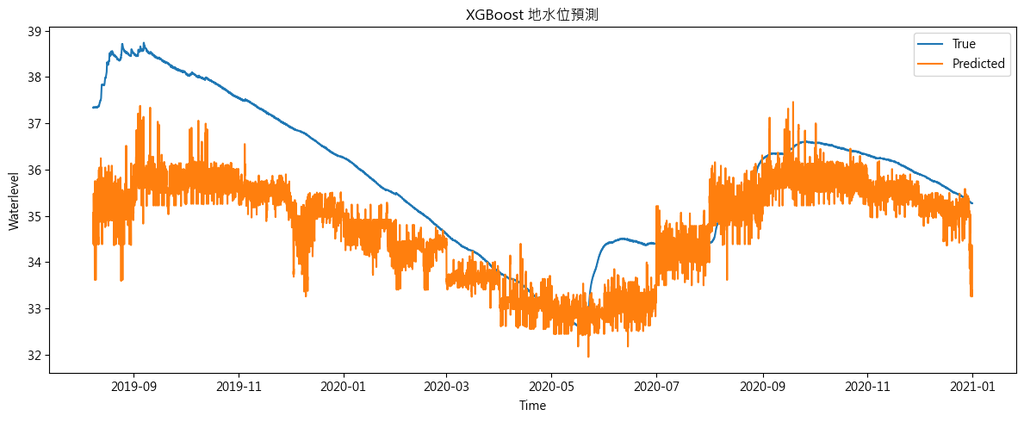

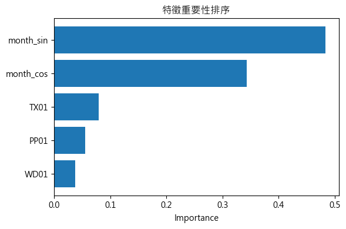

```
Fitting 5 folds for each of 81 candidates, totalling 405 fits
最佳參數： {'colsample_bytree': 0.8, 'learning_rate': 0.5, 'max_depth': 3, 'n_estimators': 150, 'subsample': 0.7}
RMSE: 0.2869614555148552
MAE : 0.18069821894435956
r2 : 0.9721817140455252
```

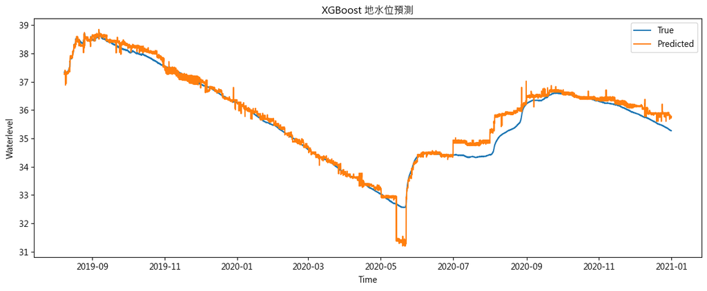

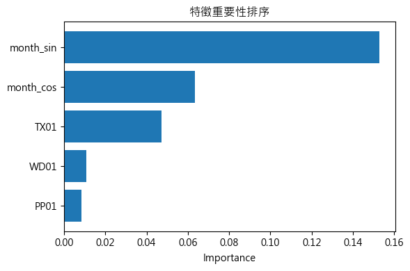

```python
###    XGBoost

# -*- coding: utf-8 -*-
"""
Created on Wed Nov 19 12:18:32 2025

@author: sy355
"""

import pandas as pd
import numpy as np
#from sklearn.preprocessing import MinMaxScaler
#pip install xgboost
from xgboost import XGBRegressor
from sklearn.model_selection import TimeSeriesSplit, GridSearchCV
from sklearn.metrics import mean_squared_error, mean_absolute_error
import matplotlib.pyplot as plt

file = pd.read_csv('data_withmonth.csv', encoding='utf-8-sig')

file['Time'] = pd.to_datetime(file['Time'])


data = file.set_index('Time')

data = data.drop(['next1hr_wl', 'previous1hr_wl', 'month'], axis = 1)
data_x = data.drop('waterlevel', axis = 1)
data_y = data[['waterlevel']]

seq_len = 1 #前24小時預測後1小時


data_x = np.array(data_x)
data_y = np.array(data_y)

#空list
X = []
y = []

#產生序列資料
for i in range(len(data_x) - seq_len):

    #前24小時的所有資料
    X.append(data_x[i:i+seq_len, :])

    #第25小時的waterlevel
    y.append(data_y[i+seq_len, -1])

#轉成array
X = np.array(X)
y = np.array(y)

#攤平成XGBoost可以用的2D特徵
n_samples, timesteps, n_features = X.shape
X_flat = X.reshape(n_samples, timesteps * n_features)

#訓練80% & 資料集20%
train_size = int(len(X_flat) * 0.8)
X_train, X_test = X_flat[:train_size], X_flat[train_size:]
y_train, y_test = y[:train_size], y[train_size:]

#超參數組合
param_grid = {
    'n_estimators': [50, 100, 150],
    'max_depth': [3, 6, 9],
    'learning_rate': [0.1, 0.3, 0.5],
    'subsample': [0.7, 0.8, 0.9],
    'colsample_bytree': [0.8]
}

#用於時間序列的交叉驗證
tscv = TimeSeriesSplit(n_splits=5)

###XGBOOST模型###
model = XGBRegressor(
    objective='reg:squarederror',
    tree_method='hist'
)

grid_search = GridSearchCV(
    estimator=model,
    param_grid=param_grid,
    scoring='neg_mean_squared_error',   # RMSE 最適用
    cv=tscv,
    n_jobs=-1,      # 用多核心加速
    verbose=1
)

grid_search.fit(X_train, y_train)

print("最佳參數：", grid_search.best_params_)

#在測試集預測
model = grid_search.best_estimator_
y_pred_scale = model.predict(X_test)

#計算誤差
rmse = np.sqrt(mean_squared_error(y_test, y_pred_scale))
mae = mean_absolute_error(y_test, y_pred_scale)
r = np.corrcoef(y_test, y_pred_scale)[0, 1]
r2 = r ** 2

print("RMSE:", rmse)
print("MAE :", mae)
print("r2 :", r2)


#補上時間序列提供繪圖
y_start = seq_len
time_test = data.index[y_start + train_size : y_start + train_size + len(y_test)]

#畫圖：實際 vs 預測

#畫圖中文字型+負號
plt.rcParams['font.sans-serif'] = ['Microsoft JhengHei']
plt.rcParams['axes.unicode_minus']=False

plt.figure(figsize=(12, 5))
plt.plot(time_test, y_test, label="True")
plt.plot(time_test, y_pred_scale, label="Predicted")
plt.legend()
plt.xlabel("Time")
plt.ylabel("Waterlevel")
plt.title("XGBoost 地水位預測")
plt.tight_layout()
plt.show()

#特徵重要性分析
feature_names = [col for col in data.columns if col != 'waterlevel'] #特徵名稱
importance = model.feature_importances_ #取得每個flattened feature的重要性

feature_group = {col: 0 for col in feature_names} #特徵加總前先歸0

#把24小時內同一個欄位的importance加總在一起
for i, imp in enumerate(importance):
    # i是 flatten後的index（0 ~ seq_len*n_features-1）
    # 用「% n_features」還原它是哪一個欄位（TX01 / WD01 / PP01 / waterlevel）
    col_idx = i % n_features
    col_name = data.columns[col_idx]

    if col_name in feature_group:   # 只加 TX01, WD01, PP01
       feature_group[col_name] += imp

#轉成 DataFrame方便排序&繪圖
importance_group_df = pd.DataFrame({
                                    'feature': list(feature_group.keys()),
                                    'importance': list(feature_group.values())
                                    })
#依重要性排序（由小到大，搭配橫向長條圖比較好看）
importance_group_df = importance_group_df.sort_values(by='importance', ascending=False)

#繪圖
#畫圖中文字型+負號
plt.rcParams['font.sans-serif'] = ['Microsoft JhengHei']
plt.rcParams['axes.unicode_minus']=False
plt.figure(figsize=(6, 4))
plt.barh(importance_group_df['feature'], importance_group_df['importance'])
plt.gca().invert_yaxis()
plt.xlabel("Importance")
plt.title("特徵重要性排序")
plt.tight_layout()
plt.show()



import pandas as pd
import numpy as np
from xgboost import XGBRegressor
from sklearn.model_selection import TimeSeriesSplit, GridSearchCV
from sklearn.metrics import mean_squared_error, mean_absolute_error
import matplotlib.pyplot as plt

file = pd.read_csv('data_withmonth.csv', encoding='utf-8-sig')
file['Time'] = pd.to_datetime(file['Time'])

data = file.set_index('Time')
data = data.drop(['next1hr_wl', 'previous1hr_wl', 'month'], axis = 1)
#data = data.drop('SS01', axis = 1)
data_x = data
data_y = data[['waterlevel']]

seq_len = 1 #前12小時預測後1小時

data_x = np.array(data_x)
data_y = np.array(data_y)

#空list
X = []
y = []

#產生序列資料
for i in range(len(data_x) - seq_len):

    #前24小時的所有資料
    X.append(data_x[i:i+seq_len, :])

    #第25小時的waterlevel
    y.append(data_y[i+seq_len, -1])

#轉成array
X = np.array(X)
y = np.array(y)

#攤平成XGBoost可以用的2D特徵
n_samples, timesteps, n_features = X.shape
X_flat = X.reshape(n_samples, timesteps * n_features)

#訓練80% & 測試集20%
train_size = int(len(X_flat) * 0.8)
X_train, X_test = X_flat[:train_size], X_flat[train_size:]
y_train, y_test = y[:train_size], y[train_size:]

#超參數組合
param_grid = {
    'n_estimators': [50, 100, 150],
    'max_depth': [3, 6, 9],
    'learning_rate': [0.1, 0.3, 0.5],
    'subsample': [0.7, 0.8, 0.9],
    'colsample_bytree': [0.8]
}

#用於時間序列的交叉驗證
tscv = TimeSeriesSplit(n_splits=5)

###XGBOOST模型###
model = XGBRegressor(
    objective='reg:squarederror',
    tree_method='hist'
)

grid_search = GridSearchCV(
    estimator=model,
    param_grid=param_grid,
    scoring='neg_mean_squared_error',   # RMSE 最適用
    cv=tscv,
    n_jobs=-1,      # 用多核心加速
    verbose=1
)

grid_search.fit(X_train, y_train)

print("最佳參數：", grid_search.best_params_)

#在測試集預測
model = grid_search.best_estimator_
y_pred_scale = model.predict(X_test)

#計算誤差
rmse = np.sqrt(mean_squared_error(y_test, y_pred_scale))
mae = mean_absolute_error(y_test, y_pred_scale)
r = np.corrcoef(y_test, y_pred_scale)[0, 1]
r2 = r ** 2

print("RMSE:", rmse)
print("MAE :", mae)
print("r2 :", r2)

#補上時間序列提供繪圖
y_start = seq_len
time_test = data.index[y_start + train_size : y_start + train_size + len(y_test)]

#畫圖：實際 vs 預測

#畫圖中文字型+負號
plt.rcParams['font.sans-serif'] = ['Microsoft JhengHei']
plt.rcParams['axes.unicode_minus']=False

plt.figure(figsize=(12, 5))
plt.plot(time_test, y_test, label="True")
plt.plot(time_test, y_pred_scale, label="Predicted")
plt.legend()
plt.xlabel("Time")
plt.ylabel("Waterlevel")
plt.title("XGBoost 地水位預測")
plt.tight_layout()
plt.show()

#特徵重要性分析
feature_names = [col for col in data.columns if col != 'waterlevel'] #特徵名稱
#feature_names = [col for col in data.columns] #特徵名稱
importance = model.feature_importances_ #取得每個flattened feature的重要性

feature_group = {col: 0 for col in feature_names} #特徵加總前先歸0

#把24小時內同一個欄位的importance加總在一起
for i, imp in enumerate(importance):
    # i是 flatten後的index（0 ~ seq_len*n_features-1）
    # 用「% n_features」還原它是哪一個欄位（TX01 / WD01 / PP01 / waterlevel）
    col_idx = i % n_features
    col_name = data.columns[col_idx]

    if col_name in feature_group:   # 只加 TX01, WD01, PP01
       feature_group[col_name] += imp

#轉成 DataFrame方便排序&繪圖
importance_group_df = pd.DataFrame({
                                    'feature': list(feature_group.keys()),
                                    'importance': list(feature_group.values())
                                    })
#依重要性排序（由小到大，搭配橫向長條圖比較好看）
importance_group_df = importance_group_df.sort_values(by='importance', ascending=False)

#繪圖
#畫圖中文字型+負號
plt.rcParams['font.sans-serif'] = ['Microsoft JhengHei']
plt.rcParams['axes.unicode_minus']=False
plt.figure(figsize=(6, 4))
plt.barh(importance_group_df['feature'], importance_group_df['importance'])
plt.gca().invert_yaxis()
plt.xlabel("Importance")
plt.title("特徵重要性排序")
plt.tight_layout()
plt.show()
```

# 參考資料

Ayus, I., Natarajan, N. & Gupta, D. (2023). Prediction of Water Level Using Machine Learning and Deep Learning Techniques. Iran J Sci Technol Trans Civ Eng 47, 2437–2447 . https://doi.org/10.1007/s40996-023-01053-6

D. H. Nguyen, X. Hien Le, J. -Y. Heo and D. -H. Bae (2021). "Development of an Extreme Gradient Boosting Model Integrated With Evolutionary Algorithms for Hourly Water Level Prediction," in IEEE Access, vol. 9, pp. 125853-125867, 2021, doi: 10.1109/ACCESS.2021.3111287.

Hsieh, W. (2023). Introduction to Environmental Data Science. Cambridge: Cambridge University Press. doi:10.1017/9781107588493

Musie, W and Gonfa, G. (2023). Fresh water resource, scarcity, water salinity challenges and possible remedies: A review. Heliyon, 9, 8. https://doi.org/10.1016/j.heliyon.2023.e18685.

水利署全球資訊網 https://www.wra.gov.tw/